# Part I - Ford Go Bike Trip Data

## by Mustafe Mohamed Abdulahi

## Introduction

This data set contains a single csv file and consists of information about individual bike-sharing system covering the greater San Francisco Bay area. The data features include tripduration (secs), start_time, end_time, user information i.e (user_type, age), and some other variable.

## Preliminary Wrangling

```python
# import all packages and set plots to be embedded inline
import numpy as np
import pandas as pd
import matplotlib.pyplot as plt
import seaborn as sb
import datetime as dt
from datetime import datetime
plt.style.use('ggplot')
%matplotlib inline
```

```python
# load the dataset into a pandas dataframe
df = pd.read_csv("fordgobiketripdata.csv")
```

```python
# show the top 5 records
df.head(5)
```

|  | duration_sec | start_time | end_time | start_station_id | start_station_name | start_station_latitude | start_station_longitude | end_station_id | end_station_name | end_station_latitude | end_station_longitude | bike_id | user_type | member_birth_year | member_gender | bike_share_for_all_trip |
| --- | --- | --- | --- | --- | --- | --- | --- | --- | --- | --- | --- | --- | --- | --- | --- | --- |
| 0 | 52185 | 2019-02-28 17:32:10.1450 | 2019-03-01 08:01:55.9750 | 21.0 | Montgomery St BART Station (Market St at 2nd St) | 37.789625 | -122.400811 | 13.0 | Commercial St at Montgomery St | 37.794231 | -122.402923 | 4902 | Customer | 1984.0 | Male | No |
| 1 | 42521 | 2019-02-28 18:53:21.7890 | 2019-03-01 06:42:03.0560 | 23.0 | The Embarcadero at Steuart St | 37.791464 | -122.391034 | 81.0 | Berry St at 4th St | 37.775880 | -122.393170 | 2535 | Customer | NaN | NaN | No |
| 2 | 61854 | 2019-02-28 12:13:13.2180 | 2019-03-01 05:24:08.1460 | 86.0 | Market St at Dolores St | 37.769305 | -122.426826 | 3.0 | Powell St BART Station (Market St at 4th St) | 37.786375 | -122.404904 | 5905 | Customer | 1972.0 | Male | No |
| 3 | 36490 | 2019-02-28 17:54:26.0100 | 2019-03-01 04:02:36.8420 | 375.0 | Grove St at Masonic Ave | 37.774836 | -122.446546 | 70.0 | Central Ave at Fell St | 37.773311 | -122.444293 | 6638 | Subscriber | 1989.0 | Other | No |
| 4 | 1585 | 2019-02-28 23:54:18.5490 | 2019-03-01 00:20:44.0740 | 7.0 | Frank H Ogawa Plaza | 37.804562 | -122.271738 | 222.0 | 10th Ave at E 15th St | 37.792714 | -122.248780 | 4898 | Subscriber | 1974.0 | Male | Yes |

```python
# Identify missing Values
missing_data = df.isnull()
missing_data.head()
```

|  | duration_sec | start_time | end_time | start_station_id | start_station_name | start_station_latitude | start_station_longitude | end_station_id | end_station_name | end_station_latitude | end_station_longitude | bike_id | user_type | member_birth_year | member_gender | bike_share_for_all_trip |
| --- | --- | --- | --- | --- | --- | --- | --- | --- | --- | --- | --- | --- | --- | --- | --- | --- |
| 0 | False | False | False | False | False | False | False | False | False | False | False | False | False | False | False | False |
| 1 | False | False | False | False | False | False | False | False | False | False | False | False | False | True | True | False |
| 2 | False | False | False | False | False | False | False | False | False | False | False | False | False | False | False | False |
| 3 | False | False | False | False | False | False | False | False | False | False | False | False | False | False | False | False |
| 4 | False | False | False | False | False | False | False | False | False | False | False | False | False | False | False | False |

```python
# count the missing Values
for c in missing_data.columns.values.tolist():
    print(c)
    print(missing_data[c].value_counts())
    print("")
```

```
duration_sec
False    183412
Name: duration_sec, dtype: int64

start_time
False    183412
Name: start_time, dtype: int64

end_time
False    183412
Name: end_time, dtype: int64

start_station_id
False    183215
True        197
Name: start_station_id, dtype: int64

start_station_name
False    183215
True        197
Name: start_station_name, dtype: int64

start_station_latitude
False    183412
Name: start_station_latitude, dtype: int64

start_station_longitude
False    183412
Name: start_station_longitude, dtype: int64

end_station_id
False    183215
True        197
Name: end_station_id, dtype: int64

end_station_name
False    183215
True        197
Name: end_station_name, dtype: int64

```

[output cut: 14 more lines]

```
Name: user_type, dtype: int64

member_birth_year
False    175147
True       8265
Name: member_birth_year, dtype: int64

member_gender
False    175147
True       8265
Name: member_gender, dtype: int64

bike_share_for_all_trip
False    183412
Name: bike_share_for_all_trip, dtype: int64
```

### Observation on missing data

###### start_station_id: 197 Missing data

###### start_station_name: 197 Missing data

###### end_station_id: 197 Missing data

###### end_station_name: 197 Missing data

###### member_birth_year: 8265 Missing data

###### member_gender: 8265 Missing data

### Deal with missing data

#### How we do deal with missing data?

Well, we have two way to deal with it.

1. drop data - drop the whole row or column: Choose this option if most entries in the column are empty or you don't need the columns.
2. Replace by the mean, frequence or other function.

#### drop these columns `start_station_id, start_station_name, end_station_id, end_station_name`since we don't them in our analysis.

```python
df.drop(["start_station_id", "start_station_name", "end_station_id", "end_station_name"], axis = 1, inplace = True)
```

```python
df.info()
```

```
<class 'pandas.core.frame.DataFrame'>
RangeIndex: 183412 entries, 0 to 183411
Data columns (total 12 columns):
 #   Column                   Non-Null Count   Dtype
---  ------                   --------------   -----
 0   duration_sec             183412 non-null  int64
 1   start_time               183412 non-null  object
 2   end_time                 183412 non-null  object
 3   start_station_latitude   183412 non-null  float64
 4   start_station_longitude  183412 non-null  float64
 5   end_station_latitude     183412 non-null  float64
 6   end_station_longitude    183412 non-null  float64
 7   bike_id                  183412 non-null  int64
 8   user_type                183412 non-null  object
 9   member_birth_year        175147 non-null  float64
 10  member_gender            175147 non-null  object
 11  bike_share_for_all_trip  183412 non-null  object
dtypes: float64(5), int64(2), object(5)
memory usage: 16.8+ MB
```

```python
# Check for duplicates
df.duplicated().sum()
```

```
0
```

```python
# How many unique Id do we have in the dataset
df.bike_id.nunique()
```

```
4646
```

```python
# Check for stats
df.describe()
```

|  | duration_sec | start_station_latitude | start_station_longitude | end_station_latitude | end_station_longitude | bike_id | member_birth_year |
| --- | --- | --- | --- | --- | --- | --- | --- |
| count | 183412.000000 | 183412.000000 | 183412.000000 | 183412.000000 | 183412.000000 | 183412.000000 | 175147.000000 |
| mean | 726.078435 | 37.771223 | -122.352664 | 37.771427 | -122.352250 | 4472.906375 | 1984.806437 |
| std | 1794.389780 | 0.099581 | 0.117097 | 0.099490 | 0.116673 | 1664.383394 | 10.116689 |
| min | 61.000000 | 37.317298 | -122.453704 | 37.317298 | -122.453704 | 11.000000 | 1878.000000 |
| 25% | 325.000000 | 37.770083 | -122.412408 | 37.770407 | -122.411726 | 3777.000000 | 1980.000000 |
| 50% | 514.000000 | 37.780760 | -122.398285 | 37.781010 | -122.398279 | 4958.000000 | 1987.000000 |
| 75% | 796.000000 | 37.797280 | -122.286533 | 37.797320 | -122.288045 | 5502.000000 | 1992.000000 |
| max | 85444.000000 | 37.880222 | -121.874119 | 37.880222 | -121.874119 | 6645.000000 | 2001.000000 |

## Data Quality

1. Remove unwanted columns
2. Correct erroneous data types for (start_time, end_time, bike_id, and user_type)

## Cleaning

### Define:

Drop unwanted columns:`start_station_latitude,start_station_longitude, end_station_latitude, end_station_longitude`

### Code

```python
#  drop unwanted columns We drop 'NaN' values
df.drop(['start_station_latitude','start_station_longitude', 'end_station_latitude', 'end_station_longitude'], axis=1, inplace=True)
```

### Test

```python
# Verify if columns are dropped
for i,v in enumerate(df.columns):
    print(i,v)
```

```
0 duration_sec
1 start_time
2 end_time
3 bike_id
4 user_type
5 member_birth_year
6 member_gender
7 bike_share_for_all_trip
```

### Define:

Correct erroneous data types of (`start_time, end_time`) and change to datetime which is the proper datatype format

### Code

```python
# Change datatype of start_time, end_time` to datetime.
df.start_time = pd.to_datetime(df.start_time)
df.end_time = pd.to_datetime(df.end_time)
```

### Test

```python
# Verify if columns are dropped
print(df.start_time.dtype)
print(df.end_time.dtype)
```

```
datetime64[ns]
datetime64[ns]
```

```python
# create a copy of the cleaned data
df_cleaned = df.copy()
df_cleaned.head()
```

|  | duration_sec | start_time | end_time | bike_id | user_type | member_birth_year | member_gender | bike_share_for_all_trip |
| --- | --- | --- | --- | --- | --- | --- | --- | --- |
| 0 | 52185 | 2019-02-28 17:32:10.145 | 2019-03-01 08:01:55.975 | 4902 | Customer | 1984.0 | Male | No |
| 1 | 42521 | 2019-02-28 18:53:21.789 | 2019-03-01 06:42:03.056 | 2535 | Customer | NaN | NaN | No |
| 2 | 61854 | 2019-02-28 12:13:13.218 | 2019-03-01 05:24:08.146 | 5905 | Customer | 1972.0 | Male | No |
| 3 | 36490 | 2019-02-28 17:54:26.010 | 2019-03-01 04:02:36.842 | 6638 | Subscriber | 1989.0 | Other | No |
| 4 | 1585 | 2019-02-28 23:54:18.549 | 2019-03-01 00:20:44.074 | 4898 | Subscriber | 1974.0 | Male | Yes |

```python
df_cleaned.info()
```

```
<class 'pandas.core.frame.DataFrame'>
RangeIndex: 183412 entries, 0 to 183411
Data columns (total 8 columns):
 #   Column                   Non-Null Count   Dtype
---  ------                   --------------   -----
 0   duration_sec             183412 non-null  int64
 1   start_time               183412 non-null  datetime64[ns]
 2   end_time                 183412 non-null  datetime64[ns]
 3   bike_id                  183412 non-null  int64
 4   user_type                183412 non-null  object
 5   member_birth_year        175147 non-null  float64
 6   member_gender            175147 non-null  object
 7   bike_share_for_all_trip  183412 non-null  object
dtypes: datetime64[ns](2), float64(1), int64(2), object(3)
memory usage: 11.2+ MB
```

### What is the structure of your dataset?

After cleaning the dataset we have 183412 rows/recordes and 8 columns including:

Duration_Sec: How long is the trip in seconds

Start and End time: when the trip has started and whenit end.

And user information i.e User type, birth year and gender etc

### What features in the dataset do you think will help support your investigation into your feature(s) of interest?

Transforming the `start_time` and `Duration_sec` columns will be helpful in my investigation i.e trans forming the datetime column days, week, month etc, user_type, will help me find and detertmine the differences between subscribers and customers for the bike usage and their relationships.

## Exploration

##### Let's transform our data and exteract new columns (start_day, end_day, start_hour, end_hour, start_month, and end month from the start_time and end_time in our origal dataset.

```python
### Extract day, month and year columns from the start_time and end datetime
df_cleaned['start_day'] = df_cleaned['start_time'].dt.day_name()
df_cleaned['end_day'] = df_cleaned['end_time'].dt.day_name()


df_cleaned['start_hour'] = df_cleaned['start_time'].dt.hour
df_cleaned['end_hour'] = df_cleaned['end_time'].dt.hour


df_cleaned['start_month'] = df_cleaned['start_time'].dt.month_name()
df_cleaned['end_month'] = df_cleaned['end_time'].dt.month_name()

df_cleaned['start_hour'] = df_cleaned.start_hour.astype(int)
df_cleaned['end_hour'] = df_cleaned.end_hour.astype(int)

df_cleaned['dur_per_minute'] =df_cleaned['duration_sec']/60
```

```python
df_cleaned.head(3)
```

|  | duration_sec | start_time | end_time | bike_id | user_type | member_birth_year | member_gender | bike_share_for_all_trip | start_day | end_day | start_hour | end_hour | start_month | end_month | dur_per_minute |
| --- | --- | --- | --- | --- | --- | --- | --- | --- | --- | --- | --- | --- | --- | --- | --- |
| 0 | 52185 | 2019-02-28 17:32:10.145 | 2019-03-01 08:01:55.975 | 4902 | Customer | 1984.0 | Male | No | Thursday | Friday | 17 | 8 | February | March | 869.750000 |
| 1 | 42521 | 2019-02-28 18:53:21.789 | 2019-03-01 06:42:03.056 | 2535 | Customer | NaN | NaN | No | Thursday | Friday | 18 | 6 | February | March | 708.683333 |
| 2 | 61854 | 2019-02-28 12:13:13.218 | 2019-03-01 05:24:08.146 | 5905 | Customer | 1972.0 | Male | No | Thursday | Friday | 12 | 5 | February | March | 1030.900000 |

```python
# Let us create ane column from member birth year to determine our users age
df_cleaned["age"] = datetime.now().year - df_cleaned.member_birth_year
```

```python
df_cleaned.info()
```

```
<class 'pandas.core.frame.DataFrame'>
RangeIndex: 183412 entries, 0 to 183411
Data columns (total 16 columns):
 #   Column                   Non-Null Count   Dtype
---  ------                   --------------   -----
 0   duration_sec             183412 non-null  int64
 1   start_time               183412 non-null  datetime64[ns]
 2   end_time                 183412 non-null  datetime64[ns]
 3   bike_id                  183412 non-null  int64
 4   user_type                183412 non-null  object
 5   member_birth_year        175147 non-null  float64
 6   member_gender            175147 non-null  object
 7   bike_share_for_all_trip  183412 non-null  object
 8   start_day                183412 non-null  object
 9   end_day                  183412 non-null  object
 10  start_hour               183412 non-null  int64
 11  end_hour                 183412 non-null  int64
 12  start_month              183412 non-null  object
 13  end_month                183412 non-null  object
 14  dur_per_minute           183412 non-null  float64
 15  age                      175147 non-null  float64
dtypes: datetime64[ns](2), float64(3), int64(4), object(7)
memory usage: 22.4+ MB
```

### Let's define age category and create a new column with our age category.

#### Let make ages between:

#### 15-25 = Youth

#### 24-64 = Adult and

#### 65+ = Senior

```python
# Add a new column catagoray next age group and call it "age_group"
category = pd.cut(df_cleaned.age, bins=[15, 25, 65, 140], labels=["Youth", "Adult", "Senior"])
df_cleaned.insert(15, "age_group", category)
```

## Univariate Exploration

```python
# Lets check our column names
for i,v in enumerate(df_cleaned.columns):
    print(i,v)
```

```
0 duration_sec
1 start_time
2 end_time
3 bike_id
4 user_type
5 member_birth_year
6 member_gender
7 bike_share_for_all_trip
8 start_day
9 end_day
10 start_hour
11 end_hour
12 start_month
13 end_month
14 dur_per_minute
15 age_group
16 age
```

##### Let us start with the usage of the bikes and find out when the most trips are taken with repect time_start i.e hour weekday, and month.

```python
base_color = sb.color_palette()[1]
```

#### Ride Frequency by hours

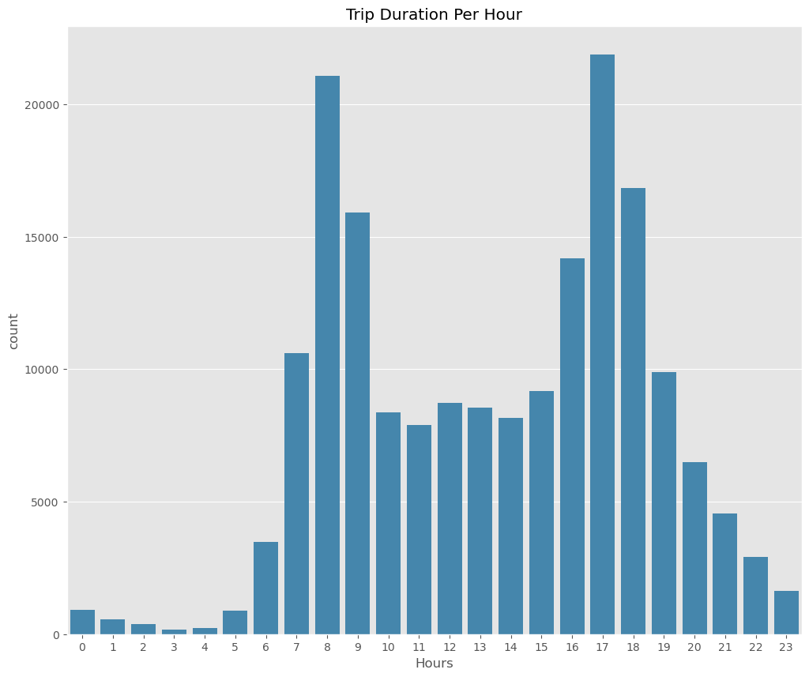

```python
# univirate analysis
# let take a look at the trip duration per hour frequence
plt.figure(figsize=(12, 10))
sb.countplot(data= df_cleaned,
            x=df_cleaned['start_hour'].sort_values(ascending=True),
            color=base_color)
plt.title("Trip Duration Per Hour")
plt.xlabel('Hours');
```

The 8th, 9th, 17th and 18th hours have the highest trip records. This is expected as it can be linked to morning rush and closing hour from work.

##### Which user types made the most trips?

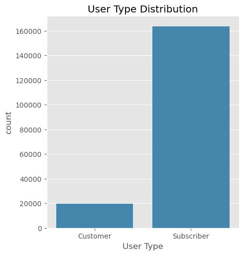

```python
# let's see Which user types made the most trip?
plt.figure(figsize=(12, 12))
sb.catplot(data = df_cleaned, x = 'user_type', kind="count", color = base_color)
plt.title('User Type Distribution')
plt.xlabel("User Type");
```

##### Observation

From this visual graph we see that Subscribers have made the most trips in data.

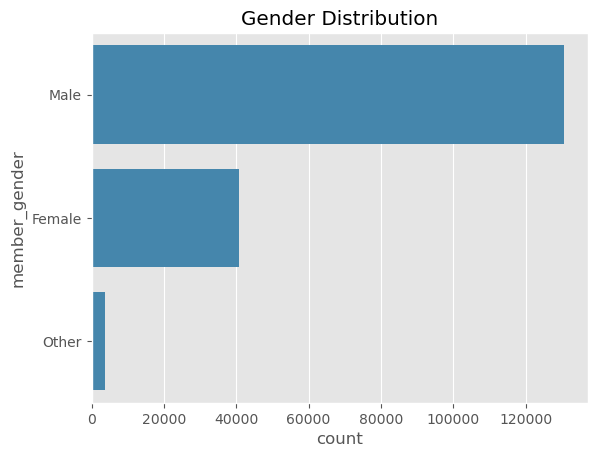

```python
#which gender is the most predominat in our data
sex_order =df.member_gender.value_counts().index
sb.countplot(y='member_gender', data= df_cleaned, color=base_color, order=sex_order)
plt.title('Gender Distribution');
```

#### Observations

In our data we have more male than anyother Gender.

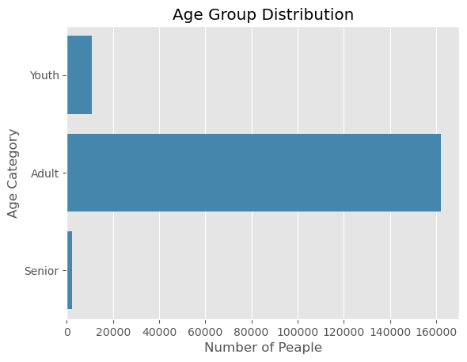

```python
# Let's plot the histogram of members age to see what the distribution of age looks like
ax = sb.countplot(data = df_cleaned, y = 'age_group', color = base_color)
# lets Show the total count
plt.title("Age Group Distribution")
plt.xlabel("Number of Peaple")
plt.ylabel("Age Category");
```

##### # In which day of the week are most bike rides occured with respect to duration in seconds

```python
# in which day of the week are most bike rides occured with respect to duration in seconds
count=df_cleaned.groupby('start_day')["duration_sec"].mean().reset_index()
count.sort_values(by=['duration_sec'],ascending=True )
```

|  | start_day | duration_sec |
| --- | --- | --- |
| 5 | Tuesday | 663.305567 |
| 6 | Wednesday | 673.671165 |
| 0 | Friday | 695.795073 |
| 4 | Thursday | 699.040998 |
| 1 | Monday | 713.159616 |
| 2 | Saturday | 902.661993 |
| 3 | Sunday | 919.746054 |

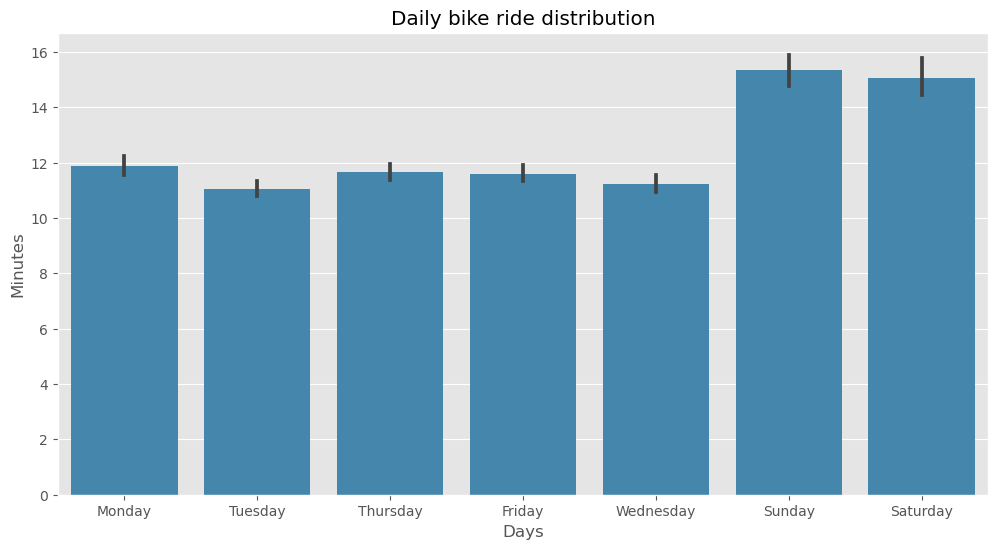

```python
# let take a look at the trip duration per day frequence
def horizontal_bar():
    plt.figure(figsize=(12, 6))
    myplot=sb.barplot(x='start_day',y= 'dur_per_minute',
                      data=df_cleaned.sort_values(by=['dur_per_minute'],ascending=True ),
                      color=base_color)
    plt.title("Daily bike ride distribution")
    plt.xlabel("Days")
    plt.ylabel("Minutes")
horizontal_bar()
```

##### Count the number of bikes shared for all trips vs Not shared?

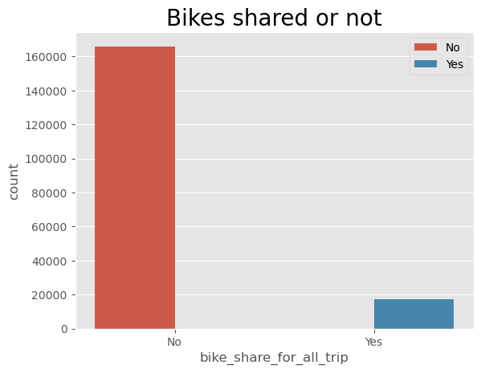

```python
## Let's Check the count the number of bike shared for all trips vs Not shared.
bake_share = sb.countplot(x = df_cleaned.bike_share_for_all_trip, hue = 'bike_share_for_all_trip', data = df_cleaned)
plt.legend()
plt.title("Bikes shared or not", fontdict = {'fontsize': 20});
```

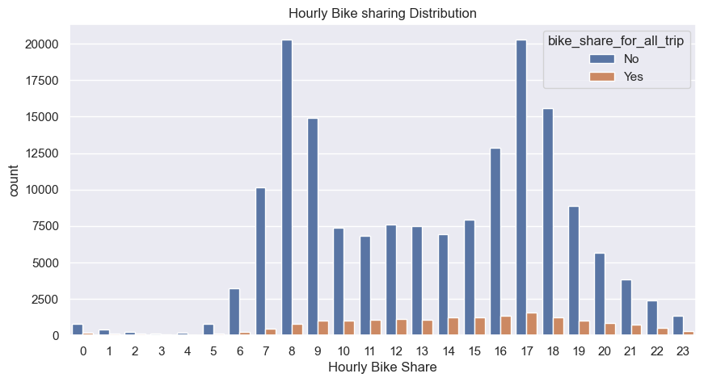

```python
# Let’s check the countplot distribution of all shared rides by hourly start and hourly end and compare the regular rides?.
plt.figure(figsize = (10,5))
sb.set(style = "darkgrid")
sb.countplot(x =df_cleaned["start_hour"].sort_values(ascending=True), hue = 'bike_share_for_all_trip', data = df_cleaned)
plt.title('Hourly Bike sharing Distribution')
plt.xlabel('Hourly Bike Share');
```

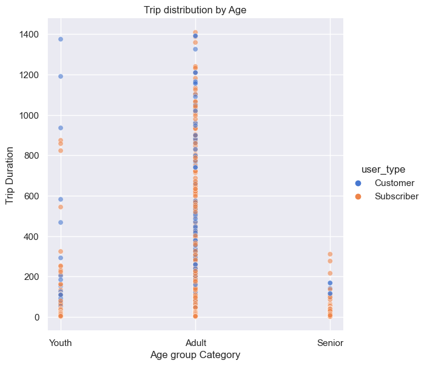

```python
# let'a plot reple plot showing distribution between age and trip duration
plt.figure(figsize=[12,8])
sb.relplot(x="age_group", y="dur_per_minute", hue="user_type",
            sizes=(40, 400), alpha=.6, palette="muted",
            height=6, data=df_cleaned)
plt.title('Trip distribution by Age')
plt.xlabel('Age group Category')
plt.ylabel('Trip Duration');
```

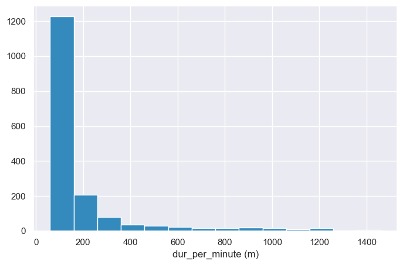

```python
# Find trip duration distribution
def histogram():
    bins = np.arange(60, df_cleaned['dur_per_minute'].max()+100, 100)
    plt.figure(figsize=[8, 5])
    plt.hist(df_cleaned['dur_per_minute'], bins = bins, color= base_color);
    plt.xlabel('dur_per_minute (m)');

histogram()
```

There's a long tail in the distribution, so let's put it on a log scale instead

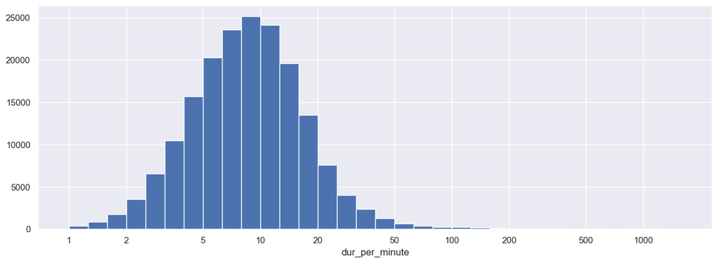

```python
def histogram():
    plt.figure(figsize=[15,5])
    bin_edges = 10 ** np.arange(0.0, np.log10(df_cleaned.dur_per_minute.max())+0.1, 0.1)
    plt.hist(data = df_cleaned, x = 'dur_per_minute', bins = bin_edges)
    plt.xscale('log')
    tick_locs = [1, 2, 5, 10, 20, 50, 100, 200, 500, 1000]
    plt.xticks(tick_locs, tick_locs)
    plt.xlabel('dur_per_minute');

histogram()
```

```python
# What is average trip duratons
df_cleaned['dur_per_minute'].mean()
```

```
12.10130725724969
```

We can see from the histogram that most rides took about (8-12) minutes. And very few rides lasted more than one hour (60 minutes). We also find trip duration avearge is 12 minutes.

### Discuss the distribution(s) of your variable(s) of interest. Were there any unusual points? Did you need to perform any transformations?

`Time' The Avarage trip duration in the dataset is 12 minutes. most trips were made by adults age between 25 to 64.

`user types` Subscribers have made the most trips in data

### Of the features you investigated, were there any unusual distributions? Did you perform any operations on the data to tidy, adjust, or change the form of the data? If so, why did you do this?

A logarithmic scale transformation was applied on duration_minutes hist plot, because there's a long tail in the distribution.

## Bivariate Exploration

> In this section, investigate relationships between pairs of variables in your data. Make sure the variables that you cover here have been introduced in some fashion in the previous section (univariate exploration).

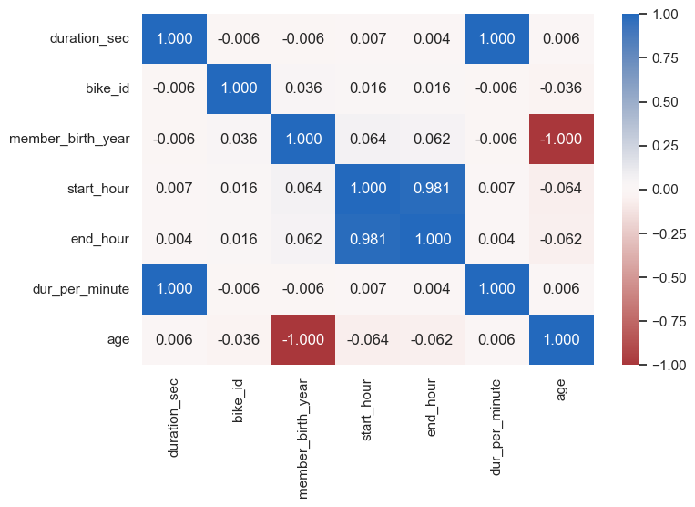

```python
# let's find the correlations between our numerial variables
corr = df_cleaned.corr()

# correlation plot
plt.figure(figsize = [8, 5])
sb.heatmap(df_cleaned.corr(), annot = True, fmt = '.3f',
           cmap = 'vlag_r', center = 0)
plt.show();
```

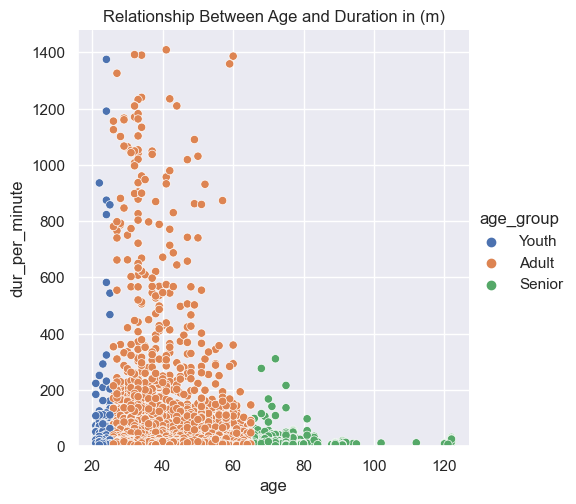

```python
# lets find the realation between age and duration_sec alone
sb.relplot(x="age", y="dur_per_minute", hue="age_group", data=df_cleaned)
plt.ylim(0)
plt.title("Relationship Between Age and Duration in (m)");
```

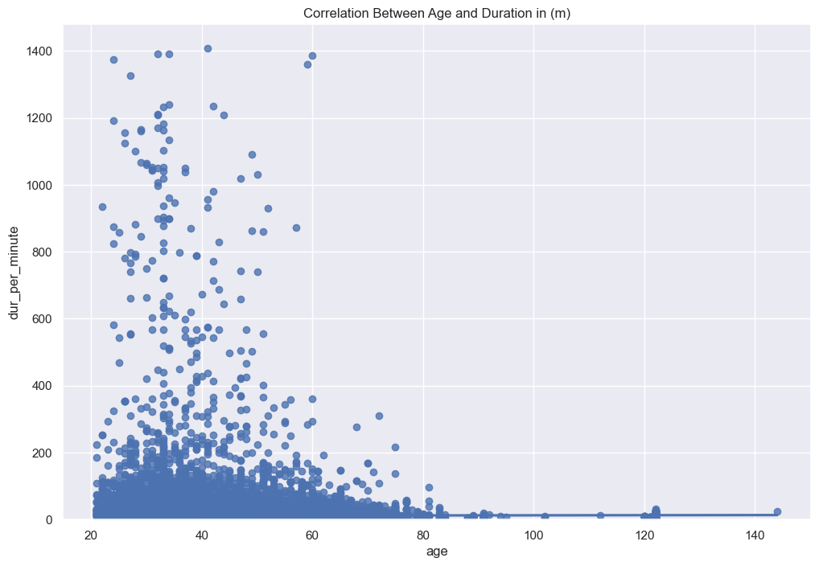

```python
# lets look the relationship more closely by coloring age group category to the relationship
plt.figure(figsize=(12, 8))
sb.regplot(x="age", y="dur_per_minute", data=df_cleaned)
plt.ylim(0)
plt.title("Correlation Between Age and Duration in (m)");
```

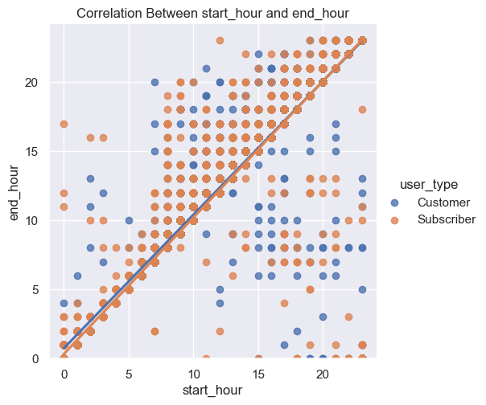

```python
plt.figure(figsize=(8, 5))
sb.lmplot(x="start_hour", y="end_hour", data=df_cleaned, hue="user_type")
plt.ylim(0)
plt.title("Correlation Between start_hour and end_hour");
```

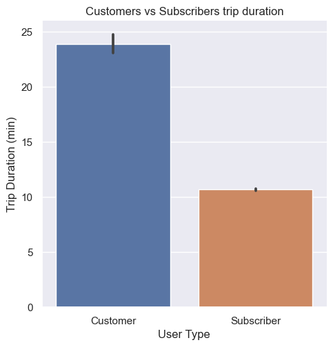

```python
# Chech trip duration  between Customers and Subscribers
sb.catplot(data=df_cleaned, kind="bar", x="user_type", y="dur_per_minute")
plt.title('Customers vs Subscribers trip duration')
plt.xlabel('User Type')
plt.ylabel('Trip Duration (min)');
```

##### Observation

The distribution shows us that customers take a longer trip than subscribers.

#### Let's look at the Categorical variable relationships in terms of user-type.

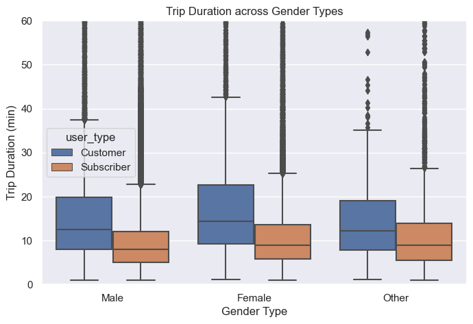

```python
# let us look at gender type
plt.figure(figsize = [8, 5])
sb.boxplot(x='member_gender', y='dur_per_minute', data = df_cleaned, hue="user_type",  order=['Male', 'Female', 'Other'])
plt.ylim(0, 60)
plt.title('Trip Duration across Gender Types')
plt.xlabel('Gender Type')
plt.ylabel('Trip Duration (min)');
```

#### Observation

Customer type users take longer trips through all the gender groups.

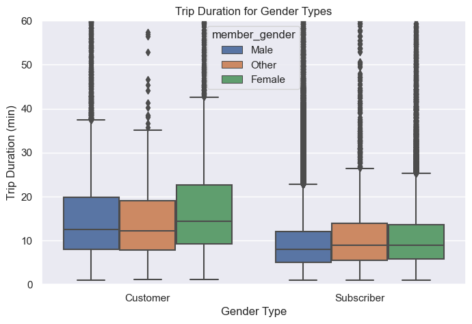

```python
# Let look at Duration across all the genders
plt.figure(figsize = [8, 5])
sb.boxplot(x='user_type', y='dur_per_minute', data = df_cleaned, hue="member_gender")
plt.ylim(0, 60)
plt.title('Trip Duration for Gender Types')
plt.xlabel('Gender Type')
plt.ylabel('Trip Duration (min)');
```

#### Observations

looking at customer boxlot, females long trips followeb by male, on other hand female and other gender are very close with the male duration is less compared female and other gender. from this visual we can deduce females take longer trips than any other gender.

### Talk about some of the relationships you observed in this part of the investigation. How did the feature(s) of interest vary with other features in the dataset?

In this part of project we looked and examined the realtionships between selected numerical and categorical variables of interest.

### Did you observe any interesting relationships between the other features (not the main feature(s) of interest)?

Looking at the relationship between gender type and duration per minute. The garph showed that females and Other genders take longer trip durations then Male which I was surprised.

## Multivariate Exploration

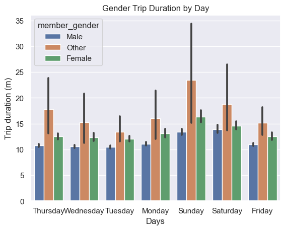

```python
# Compare daily trip duration by gender
sb.barplot(x="start_day", y="dur_per_minute",
             hue="member_gender",
             data=df_cleaned)
plt.title('Gender Trip Duration by Day')
plt.ylabel('Trip duration (m)')
plt.xlabel('Days')
```

#### Observation

Unsureprisinly as we have seen our previeous analaysis, males still have the shortest bike trip duration per day compared to female and other genders.

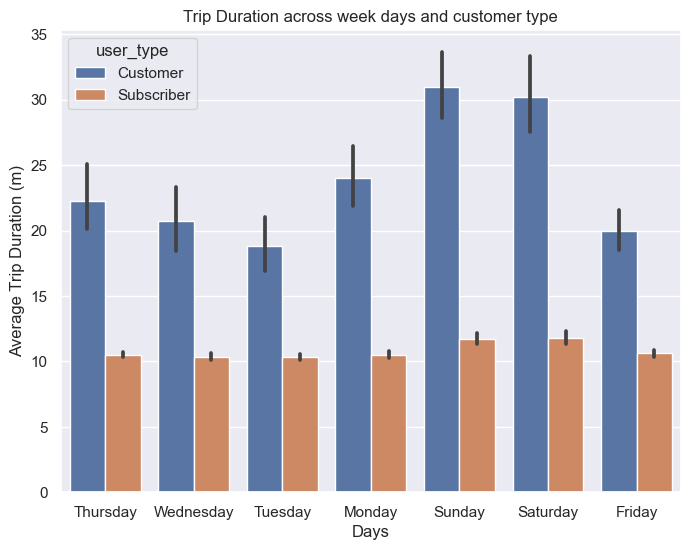

```python
# Compare Week day trip duration with respect user_type
fig = plt.figure(figsize = [8,6])
ax = sb.barplot(data = df_cleaned, x ='start_day', y = 'dur_per_minute', hue = 'user_type')
plt.title('Trip Duration across week days and customer type')
plt.xlabel('Days')
plt.ylabel('Average Trip Duration (m)')
plt.xlabel('Days')
```

### Display the number of users, type and and their age catagory.

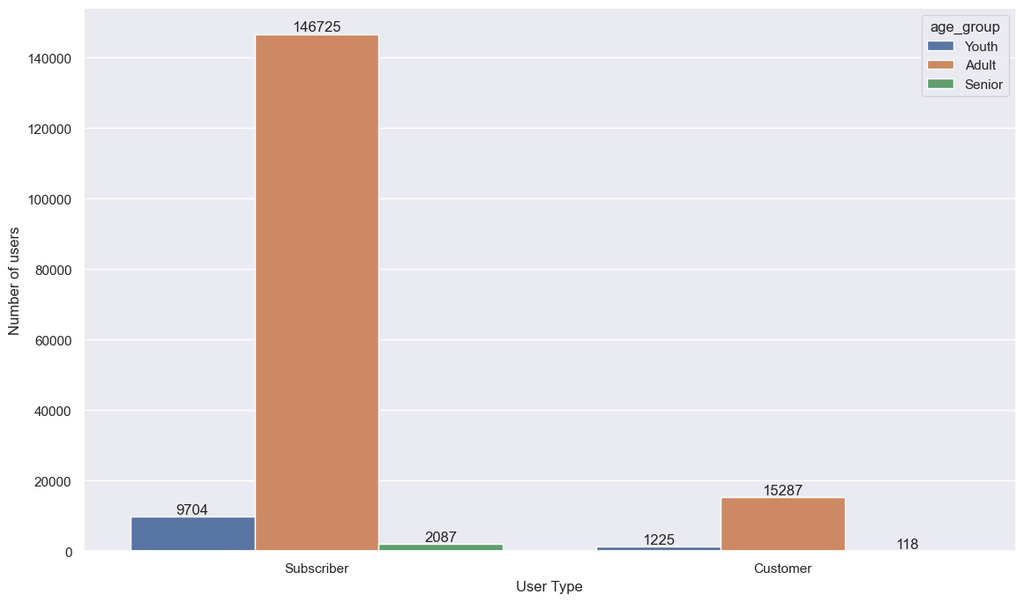

```python
#display the numbers of users, their user_typ and and their age category

plt.figure(figsize = [30, 8])
plt.subplot(1, 2, 1)
ax = sb.countplot(data=df_cleaned, x="user_type", hue="age_group",
                          order=df_cleaned.user_type.value_counts().index)
for container in ax.containers:
    ax.bar_label(container)
plt.xlabel('User Type')
plt.ylabel('Number of users');
```

#### Observations

For Customer user types, we have 15287 Adults 1225 youth, and 118 seniors.

```python
df_cleaned.to_csv('fordgobiketrip_cleaned_data.csv', index=False)
new_df = pd.read_csv("fordgobiketrip_cleaned_data.csv")
new_df.info()
```

```
<class 'pandas.core.frame.DataFrame'>
RangeIndex: 183412 entries, 0 to 183411
Data columns (total 17 columns):
 #   Column                   Non-Null Count   Dtype
---  ------                   --------------   -----
 0   duration_sec             183412 non-null  int64
 1   start_time               183412 non-null  object
 2   end_time                 183412 non-null  object
 3   bike_id                  183412 non-null  int64
 4   user_type                183412 non-null  object
 5   member_birth_year        175147 non-null  float64
 6   member_gender            175147 non-null  object
 7   bike_share_for_all_trip  183412 non-null  object
 8   start_day                183412 non-null  object
 9   end_day                  183412 non-null  object
 10  start_hour               183412 non-null  int64
 11  end_hour                 183412 non-null  int64
 12  start_month              183412 non-null  object
 13  end_month                183412 non-null  object
 14  dur_per_minute           183412 non-null  float64
 15  age_group                175146 non-null  object
 16  age                      175147 non-null  float64
dtypes: float64(3), int64(4), object(10)
memory usage: 23.8+ MB
```

### Talk about some of the relationships you observed in this part of the investigation. Were there features that strengthened each other in terms of looking at your feature(s) of interest?

Looking at the same variables, I again examined the relationship between Weekdays, gender and the trip durations and as we have seen in our previous analysis from Bivariate section Males have the shortest bike trip on weekdays.

Analazing the group age and user type distribution I found adults which is defined a ages between 25-64 in our dataset made the most trips

### Were there any interesting or surprising interactions between features?

There wasn'st any interactions that got my attention.

## Conclusions

### Key Insights from my posted questions:

My goal in this project was to answer the following simple questions:

#### Q1: Which hours of the day most trip were taken?

Answer: `8th, 9th, 17th, and 18th is when most trips happen during the day

#### Q2: Which user types made the most trips?

Answer: Subscribers have mode most trips in our dataset

#### Q4: Which user types take the longest trip with respect duration per minutes.

Answer:Customers on average take a longer trip than subscribers.

### Sources

https://seaborn.pydata.org/generated/seaborn.regplot.html https://stackoverflow.com/questions/55104819/display-count-on-top-of-seaborn-barplot https://deepnote.com/@dain-russell/bike-exploration-328b5ba1-25e4-4a35-aaad-e70146c9e182 https://seaborn.pydata.org/generated/seaborn.boxplot.html https://seaborn.pydata.org/generated/seaborn.countplot.html https://stackoverflow.com/questions/26597116/seaborn-plots-not-showing-up